## Course: VISUAL ANALYTICS FOR POLICY AND MANAGEMENT

### Prof. José Manuel Magallanes, PhD

- Visiting Professor of Computational Policy at Evans School of Public Policy and Governance, and eScience Institute Senior Data Science Fellow, University of Washington.
- Professor of Government and Political Methodology, Pontificia Universidad Católica del Perú.

# Session 5: Tabular data: Bivariate Num-Num

As always we collect…

```r
# collecting the data
link="https://github.com/EvansDataScience/data/raw/master/crime.RData"
load(file = url(link))
```

…and review the data:

```r
str(crime)
```

```
## 'data.frame':    499698 obs. of  17 variables:
##  $ Report.Number              : chr  "20130000244104" "20130000242916" "20130000904541" "20130000243875" ...
##  $ Occurred.Date              : Date, format: "2013-07-09" "2013-07-09" ...
##  $ year                       : num  2013 2013 2013 2013 2013 ...
##  $ month                      : num  7 7 7 7 7 7 7 7 7 7 ...
##  $ weekday                    : Ord.factor w/ 7 levels "Monday"<"Tuesday"<..: 2 2 2 2 2 2 2 2 2 2 ...
##  $ Occurred.Time              : num  1930 1917 1900 1900 1846 ...
##  $ Occurred.DayTime           : Ord.factor w/ 4 levels "day"<"afternoon"<..: 3 3 3 3 3 3 3 3 3 3 ...
##  $ Reported.Date              : Date, format: "2013-07-10" "2013-07-09" ...
##  $ Reported.Time              : num  1722 2052 35 1258 1846 ...
##  $ DaysToReport               : num  1 0 1 1 0 0 0 0 1 0 ...
##  $ crimecat                   : Factor w/ 20 levels "AGGRAVATED ASSAULT",..: 12 3 4 18 7 3 18 18 4 18 ...
##  $ Crime.Subcategory          : Factor w/ 30 levels "AGGRAVATED ASSAULT",..: 17 6 8 16 11 6 28 28 8 28 ...
##  $ Primary.Offense.Description: Factor w/ 144 levels "ADULT-VULNERABLE-FINANCIAL",..: 53 21 124 133 30 19 131 131 124 131 ...
##  $ Precinct                   : Factor w/ 5 levels "EAST","NORTH",..: 2 2 3 2 5 5 5 4 5 2 ...
##  $ Sector                     : Factor w/ 23 levels "6804","9512",..: 21 12 17 21 16 16 13 7 11 12 ...
##  $ Beat                       : Factor w/ 64 levels "B1","B2","B3",..: 58 33 49 58 46 46 37 16 28 31 ...
##  $ Neighborhood               : Factor w/ 58 levels "ALASKA JUNCTION",..: 51 28 37 49 46 46 15 24 15 28 ...
```

Let’s use:

- “Occurred.Date”
- “year”
- “month”
- “weekday”
- “Reported.Date”
- “DaysToReport”
- “crimecat”
- “Neighborhood”

```r
varsProject=c("Occurred.Date","year", "month", "weekday", "Reported.Date" , "DaysToReport","crimecat","Neighborhood")
crime=crime[,varsProject]
crime=crime[complete.cases(crime),]
```

## Numeric-Time data

Time belongs to the interval scale. The zero does not mean absence of time, and there multipicative interpretations do not make sense: 4 pm is not twice 2 pm.

I have a date variable in this data set:

```r
summary(crime$Occurred.Date)
```

```
##         Min.      1st Qu.       Median         Mean      3rd Qu.
## "1908-12-13" "2010-10-29" "2013-10-18" "2013-08-10" "2016-05-11"
##         Max.
## "2018-11-06"
```

Let’s try some cleaning:

```r
crime[which.max(crime$Occurred.Date),]
```

[output not shown]

```r
# change Date (keep format):
crime[6783,'Occurred.Date']=as.Date('2008-12-13')
# change column year:
crime[6783,'year']=2008
```

The previous changes were easy, but I need to make changes in computed fields:

```r
#for recomputing fields:
library(lubridate)
library(magrittr) # to use "%>%"

#change the DAY of the week
crime[6783,'weekday']=wday(as.Date('2008-12-13'),
                           label=TRUE,
                           abbr = FALSE)

#change the period:

crime[6783,'DaysToReport']=difftime(crime[6783,'Reported.Date'],
                                    crime[6783,'Occurred.Date'],
                                    units = "days")%>%as.numeric()
```

With the data as is, you can request a bar plot:

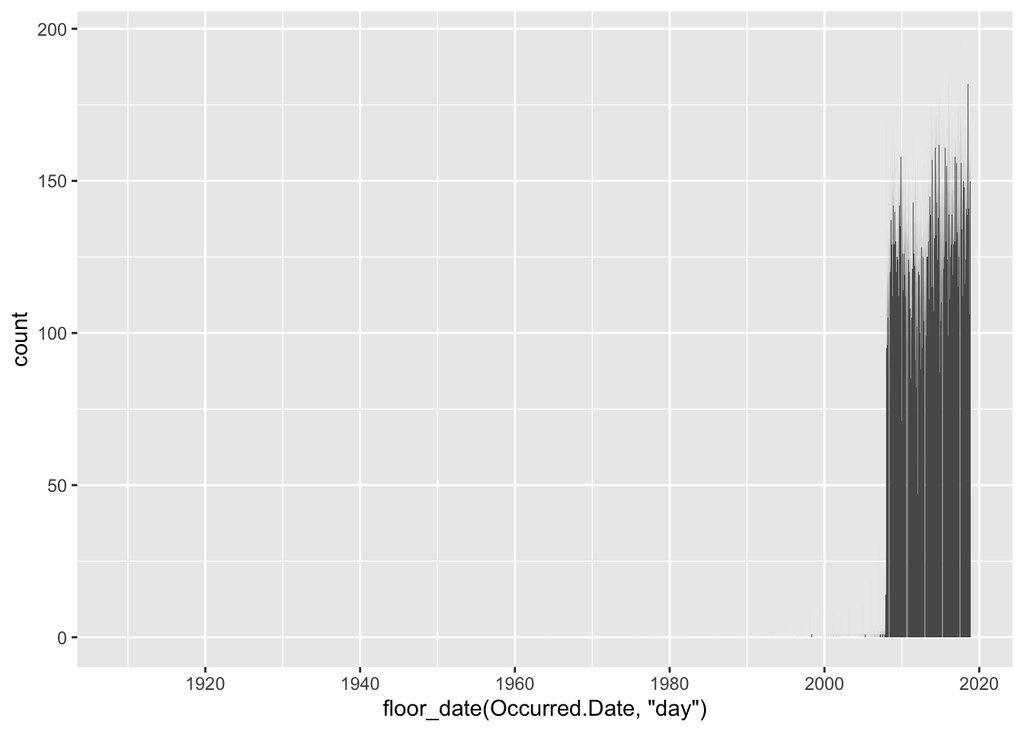

```r
# how many crimes are occurring per day since...?
library(ggplot2)
base=ggplot(crime,aes(x = floor_date(Occurred.Date, "day")))
barT1= base + geom_bar()
barT1
```

A particular period:

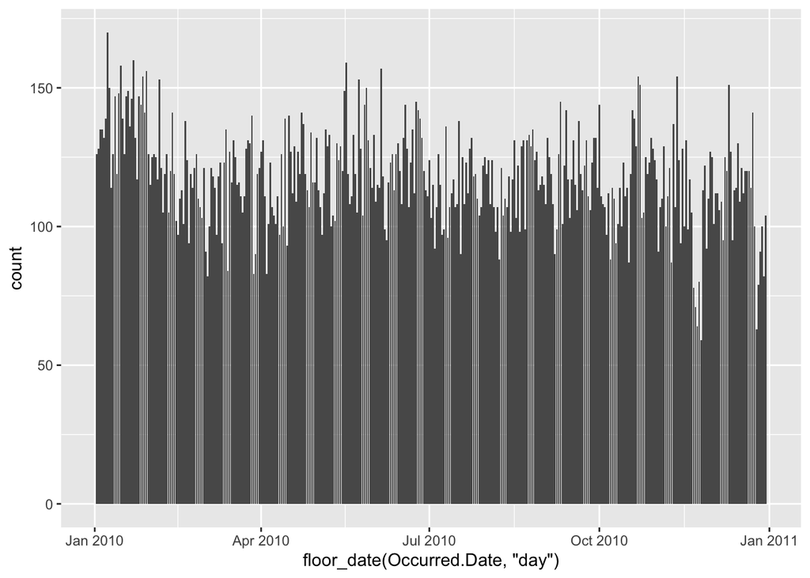

```r
Start=as.Date('2010-1-1')
End=as.Date('2010-12-31')
barT1 + scale_x_date(limits = c(Start,End))
```

A particular crime

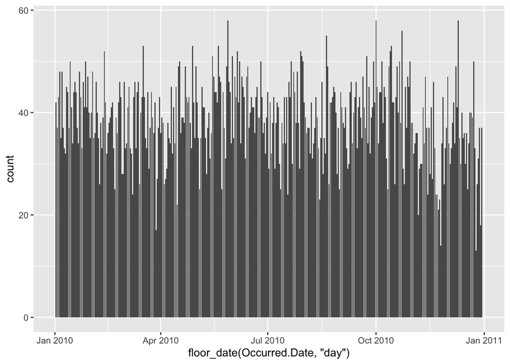

```r
# A particular crime: theft

base=ggplot(crime[crime$crimecat=="THEFT",],
            aes(x = floor_date(Occurred.Date, "day")))
barT2=base + geom_bar()
barT2 + scale_x_date(limits = c(Start,End))
```

I could make a better horizontal axis:

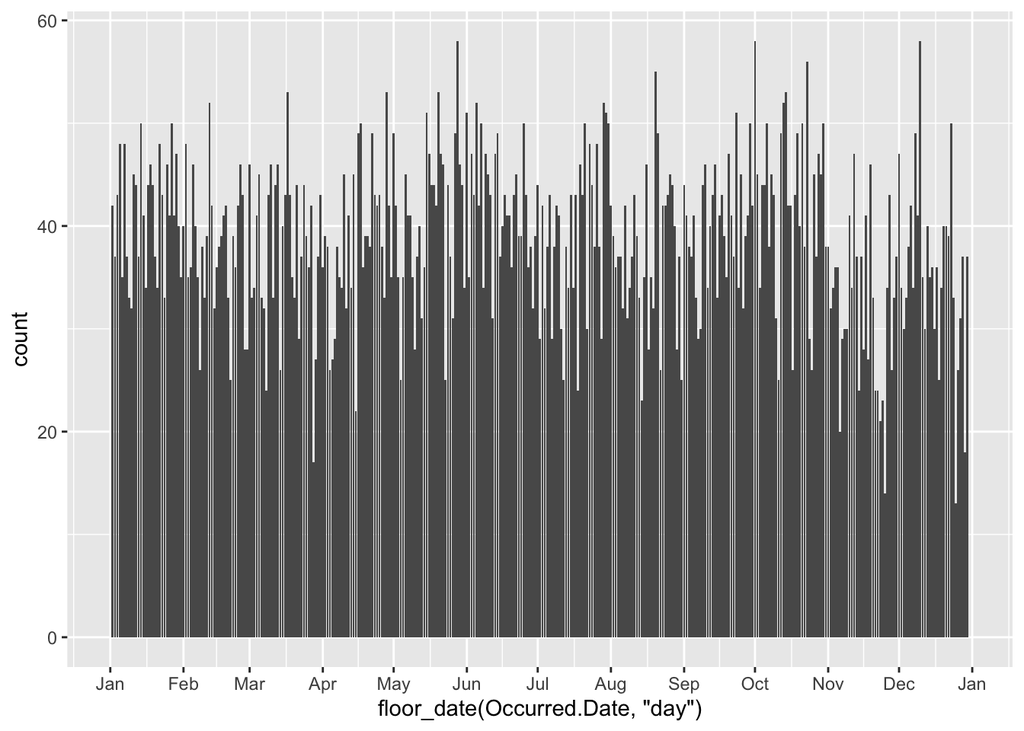

```r
library(scales) #for "date_format"
# x axis formatting
barT2 + scale_x_date(limits = c(Start,End),
                    labels = date_format("%b"),
                    date_breaks = "1 month")
```

We can use facets:

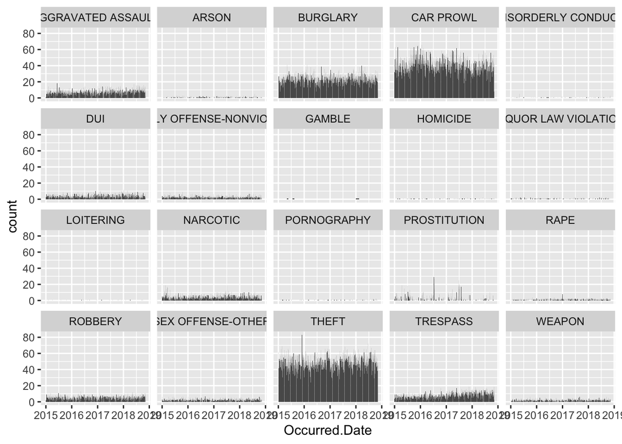

```r
# filtering and faceting
base=ggplot(data=crime[crime$year>2014,], # filter
            aes(x=Occurred.Date))
barT3=base + geom_bar(na.rm = T)
barT3 + facet_wrap(~crimecat)
```

We could re organize the previous plot but we lack some information. Let me create a frequency table:

```r
crimeDate=as.data.frame(table(crime$Occurred.Date,crime$crimecat))
names(crimeDate)=c("date",'crime','count')
#formatting column in Freq Table:
crimeDate$date=as.Date(crimeDate$date)
```

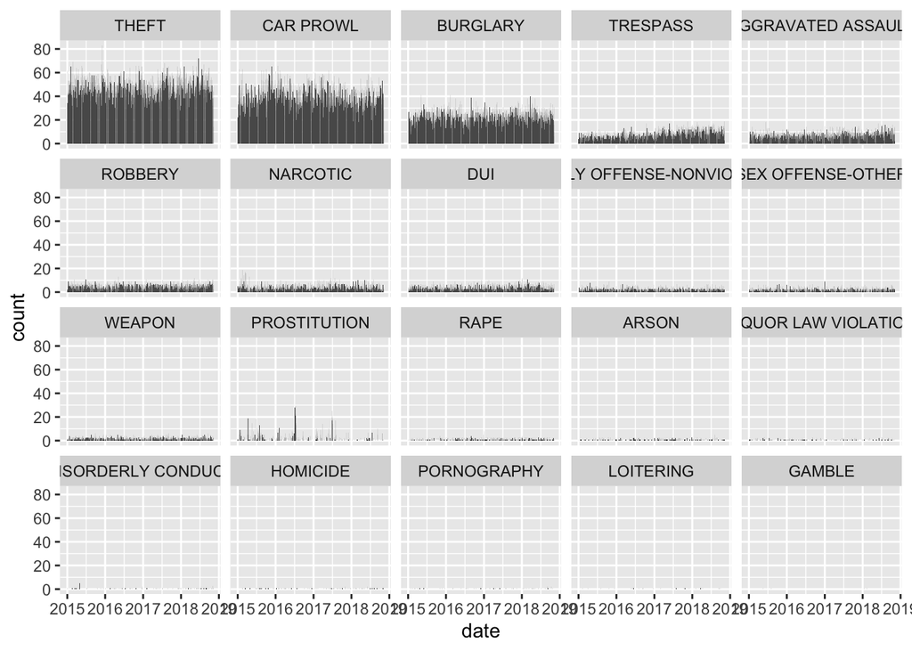

```r
base=ggplot(crimeDate[crimeDate$date>'2014-12-31',], # filter
            aes(x=date,y=count))
barT4=base + geom_bar(stat = 'identity')
barT4 + facet_wrap(~reorder(crime,-count))
```

```r
crimeDate2=as.data.frame(table(crime$Occurred.Date))
names(crimeDate2)=c("date",'count')
#formatting column in Freq Table:
crimeDate2$date=as.Date(crimeDate2$date)
```

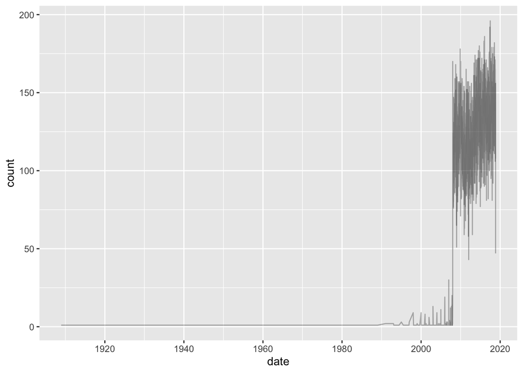

```r
base=ggplot(crimeDate2,
            aes(x=date,y=count))
base  + geom_line(alpha=0.3)
```

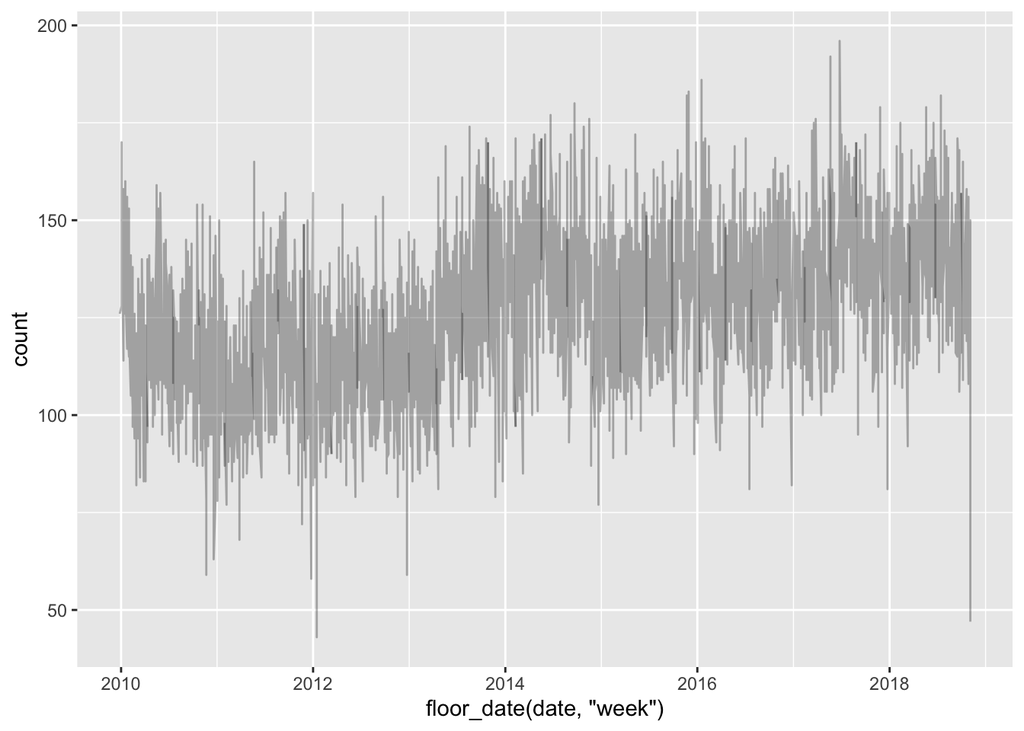

```r
base=ggplot(crimeDate2[crimeDate2$date>as.Date("2010/1/1"),],
            aes(x=floor_date(date, "week"),y=count))
base  + geom_line(alpha=0.3)
```

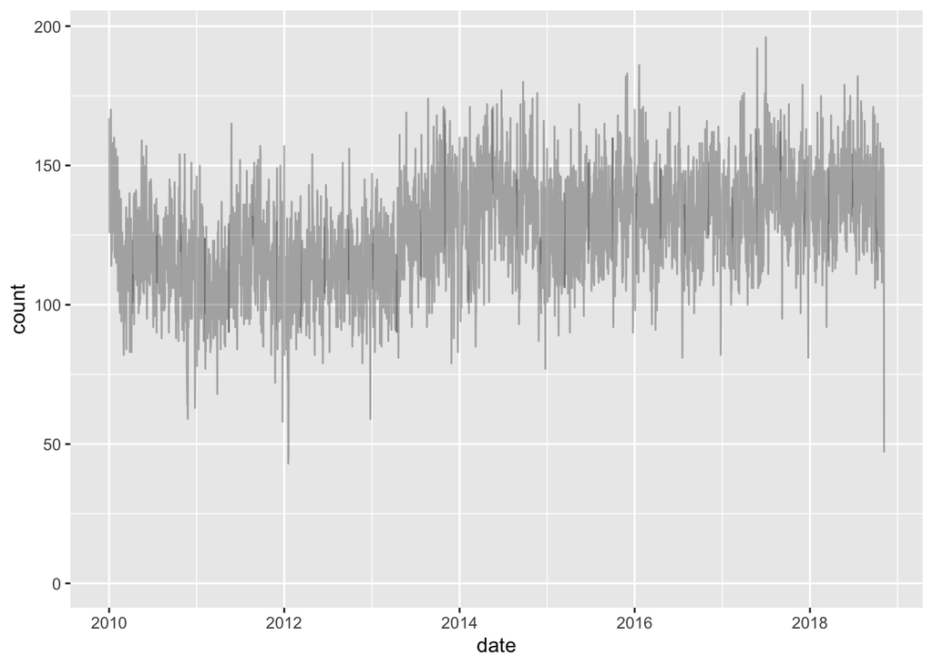

```r
min <- as.Date("2010/1/1")
max <- NA
base=ggplot(crimeDate2,
            aes(x=date,y=count))
base  + geom_line(alpha=0.3) + scale_x_date(limits = c(min, max))
```

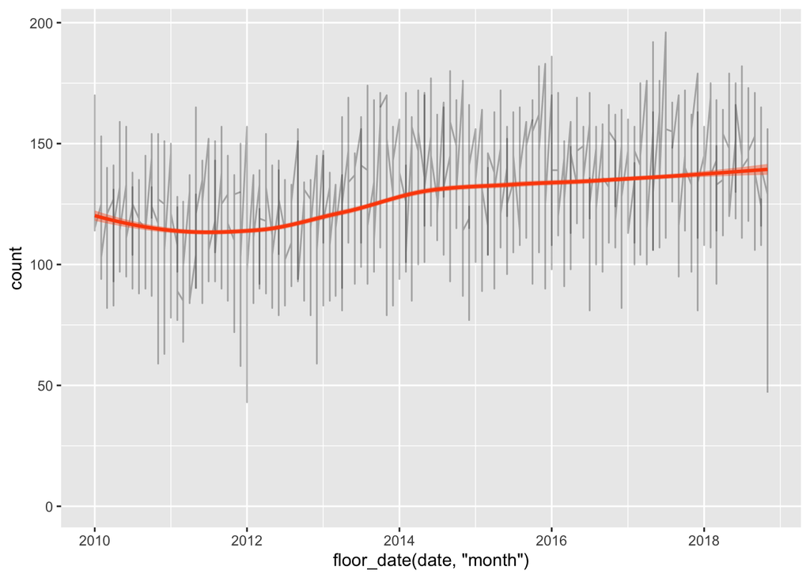

```r
min <- as.Date("2010/1/1")
max <- NA
base=ggplot(crimeDate2,
            aes(x=floor_date(date, "month"),y=count))
base  + geom_line(alpha=0.3) + scale_x_date(limits = c(min, max)) + stat_smooth(
  color = "#FC4E07", fill = "#FC4E07",
  method = "loess"
  )
```

```r
crimeDate2$year=year(crimeDate2$date)
```

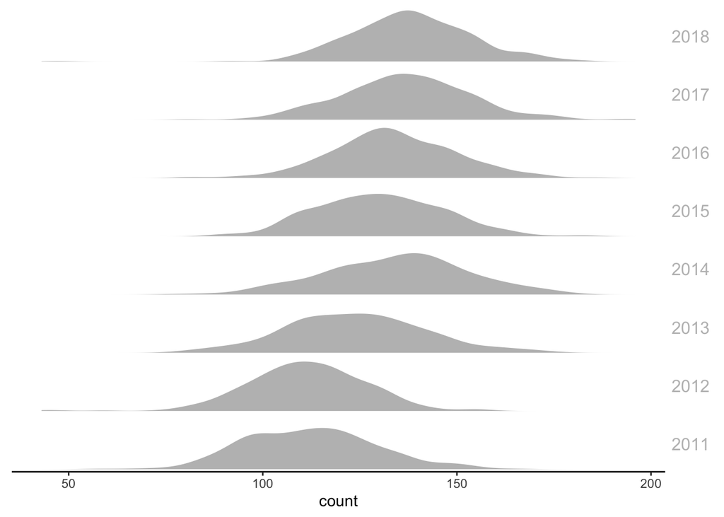

```r
ggplot(crimeDate2[crimeDate2$year>2010,],
       aes(x = count)) + geom_density(fill='grey', color=NA) +
    facet_wrap(~year,
               ncol = 1,
               strip.position = 'right',
               as.table = F) + theme_classic() +
    theme(panel.spacing.y = unit(0.1, "lines"),
          axis.title.y = element_blank(),
          axis.text.y = element_blank(),
          axis.line.y = element_blank(),
          axis.ticks.y = element_blank(),
          strip.background = element_rect(colour="white",
                                          fill="white",
                                          size=1.5),
          strip.text.y = element_text(size=12, color="grey",
                                      angle = 0))
```

## Numeric-Numeric data

The study of bivariate relationships among numerical variables is known as correlation analysis. The data we have been using has few numerical columns, but I will produce two by aggregating the original data since 2015 by *Neigborhood*:

- Aggregating days to report and neighborhood:

```r
crime2015=crime[crime$year>=2015,]
# 1. MEAN of days it takes to report a crime by neighborhood
daysByNeigh=aggregate(data=crime2015,DaysToReport~Neighborhood,mean)

# you have:
head(daysByNeigh)
```

```
##      Neighborhood DaysToReport
## 1 ALASKA JUNCTION     3.624267
## 2            ALKI     3.922434
## 3   BALLARD NORTH     4.248983
## 4   BALLARD SOUTH     3.844756
## 5        BELLTOWN     2.497066
## 6      BITTERLAKE     4.383847
```

- Aggregating crimes by neighborhood

```r
# 2. Crimes by neighborhood
crimesByNeigh=as.data.frame(100*prop.table(table(crime2015$Neighborhood)))
names(crimesByNeigh)=c('Neighborhood', 'CrimeShare')
head(crimesByNeigh)
```

```
##      Neighborhood CrimeShare
## 1 ALASKA JUNCTION  1.5335980
## 2            ALKI  0.4430042
## 3   BALLARD NORTH  2.2081485
## 4   BALLARD SOUTH  3.3167163
## 5        BELLTOWN  2.7928295
## 6      BITTERLAKE  1.8523707
```

Since both data frames have the same neighboorhood, we can make one data frame by merging them:

```r
num_num=merge(daysByNeigh,crimesByNeigh) # 'Neighborhood' is the "key"
#check after merge:
str(num_num)
```

```
## 'data.frame':    58 obs. of  3 variables:
##  $ Neighborhood: Factor w/ 58 levels "ALASKA JUNCTION",..: 1 2 3 4 5 6 7 8 9 10 ...
##  $ DaysToReport: num  3.62 3.92 4.25 3.84 2.5 ...
##  $ CrimeShare  : num  1.534 0.443 2.208 3.317 2.793 ...
```

```r
num_num$Neighborhood=as.character(num_num$Neighborhood)
```

Once we have the data organized, the clear option is the scatterplot:

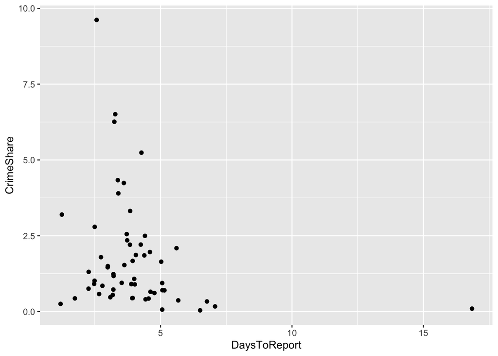

```r
base = ggplot(num_num, aes(x=DaysToReport,y=CrimeShare))
plot1= base +  geom_point()
plot1
```

We can improve the plot, this time introducing **ggrepel**:

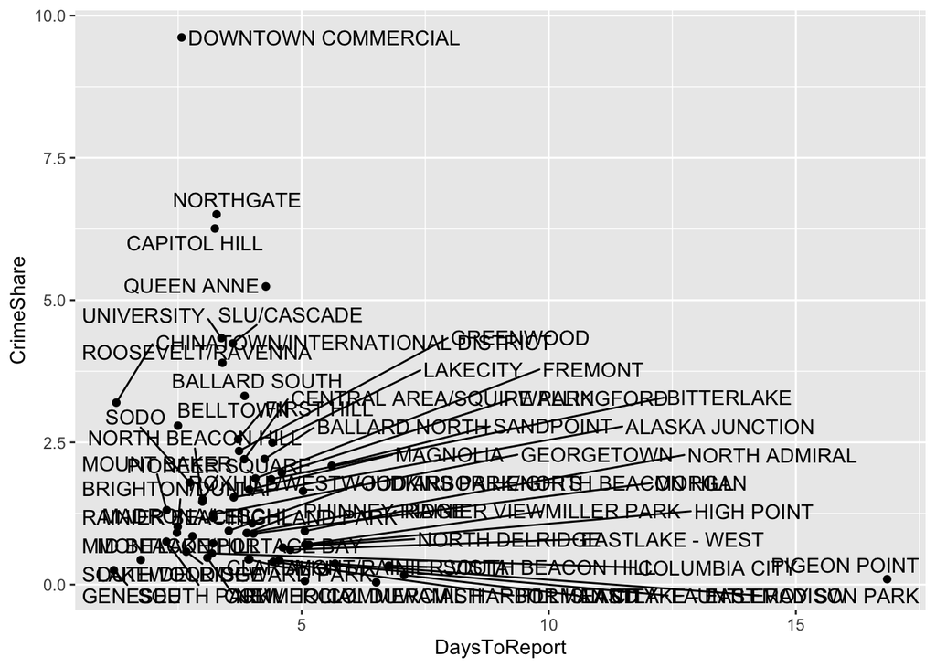

```r
library(ggrepel)
plot1 + geom_text_repel(aes(label=Neighborhood))
```

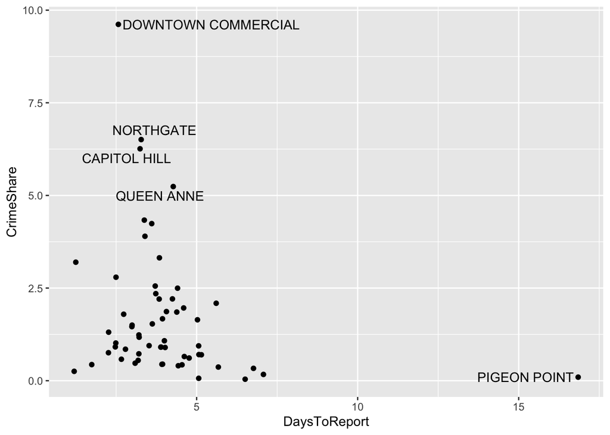

```r
plot1 + geom_text_repel(aes(label=ifelse(CrimeShare>=5 | DaysToReport>10,
                                         Neighborhood, "")))
```

An alternative, to highlight overlaping of points:

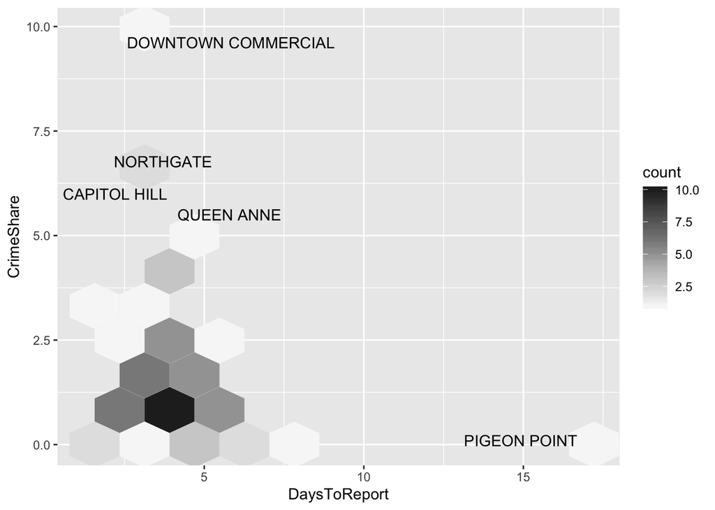

```r
scatp1 = base +  geom_hex(bins = 10)
scatp2= scatp1 + geom_text_repel(aes(label=ifelse(CrimeShare>=5 | DaysToReport>10, Neighborhood, "")))
scatp2 + scale_fill_distiller(palette ="Greys",direction=1) # try -1
```

The palettes can be selected from the [brewer colors website](http://colorbrewer2.org). Using the same palette as before, we can try a different plot (stat_density_2d):

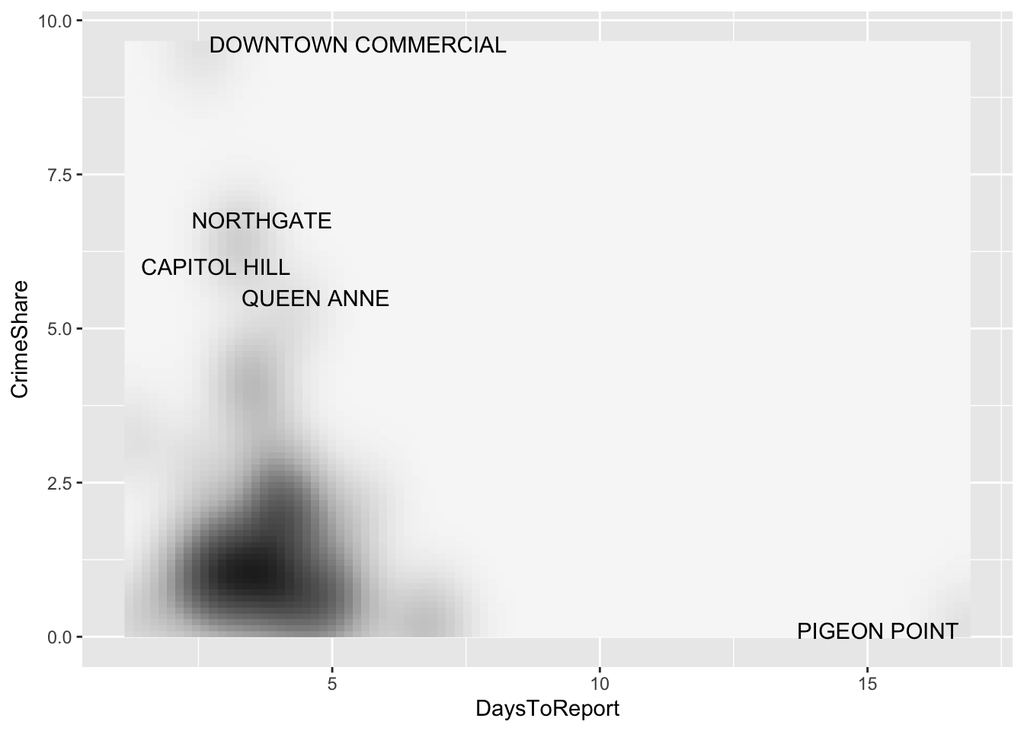

```r
base = ggplot(num_num, aes(x=DaysToReport,y=CrimeShare))
scatp1 = base +  stat_density_2d(aes(fill = ..density..),
                                 geom = "raster", contour = FALSE)
scatp2=scatp1 + geom_text_repel(aes(label=ifelse(CrimeShare>=5 | DaysToReport>10,
                                         Neighborhood, "")))
scatp3 = scatp2 +  theme(legend.position='none')
scatp4= scatp3 + scale_fill_distiller(palette="Greys", direction=1)
scatp4
```

The extra space you see can dissappear using:

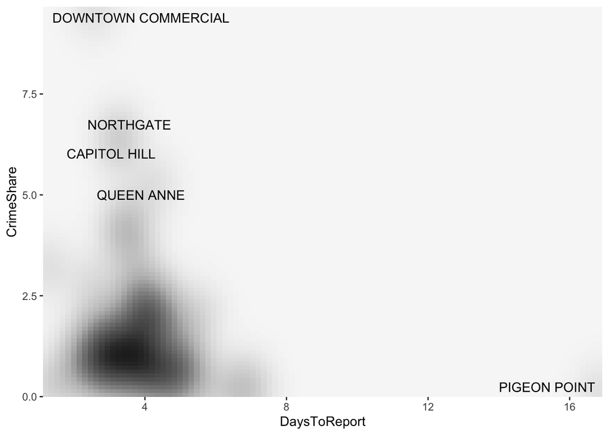

```r
scatp5 = scatp4 +  scale_x_continuous(expand = c(0, 0)) +
         scale_y_continuous(expand = c(0, 0))
scatp5
```